# P7 · Customer Lifetime Value con CLVTools

Validación fuera de tiempo en un negocio sin contrato

Fecha de publicación

17 de noviembre de 2026

## 1 Resumen ejecutivo

En un negocio sin contrato el abandono no se observa. ¿Cuántas compras hará cada cliente, sigue activo y cuánto vale?

- El Pareto/NBD predice el holdout de CDNOW con MAE 0.751, un 26% por debajo de extrapolar la tasa de cada cliente.
- El AIC elige BG/NBD y este único holdout elige Pareto/NBD, con una brecha del 4%. No declara un ganador.
- XGBoost, sin ver el holdout, mejora al baseline y queda un 21% por detrás del Pareto/NBD, con sesgo casi nulo.
- El decil superior concentra el 61.3% del CLV. Ese valor es de horizonte infinito: lo mueve el descuento, no el horizonte.

Importa porque el agregado puede ajustar bien y, aun así, subestimar a quien compra poco.

## 2 Datos y diseño temporal

CDNOW, incluido en CLVTools, es una cohorte de primeros compradores del primer trimestre de 1997: 2357 clientes y 6696 transacciones. La unidad de tiempo es la semana. La verosimilitud usa solo la ventana de estimación; el error se mide en lo que ocurrió después, contado al margen de CLVTools.

```
1997-01-01              1997-10-01                 1998-06-30
|----- estimación: 39 semanas -----|---- holdout: 38.7 semanas ----|
```

Ese corte evita la fuga: ninguna variable ni el ajuste ven compras posteriores al 1 de octubre de 1997. El objetivo del holdout es el número de transacciones con fecha estrictamente posterior al corte. Quien no vuelve entra con cero, no se elimina.

El benchmark de XGBoost usa el mismo holdout y, además, una ventana de entrenamiento anterior, porque el árbol necesita etiquetas futuras y las del holdout están prohibidas.

```
Entrenamiento:  features con semana <= 20  ->  compras en (20, 39]
Test:           features con semana <= 39  ->  compras después de 39
```

Las variables son tasas y ratios (`rate_x`, `rec_ratio`, `mean_spend`, `spend_rate`) y el objetivo del árbol es una tasa semanal, para que una ventana de 19 semanas y otra de unas 39 sean comparables. Un `stopifnot` corta la corrida si el entrenamiento ve semanas posteriores a 20. No es una equivalencia exacta: las ventanas siguen teniendo distinto largo.

## 3 Modelos

### 3.1 Pareto/NBD

**Intuición.** Mientras el cliente está “vivo” compra a un ritmo estable. En algún momento abandona para siempre, y ese momento no se observa. Un silencio largo puede ser abandono o un comprador lento.

**Modelo.** Las compras, mientras vive, son Poisson con tasa $\lambda \sim \mathrm{Gamma}(r, \alpha)$. La vida $\tau$ es exponencial con tasa $\mu \sim \mathrm{Gamma}(s, \beta)$. $\lambda$ y $\mu$ son independientes. De cada cliente se observan las compras repetidas $x$, la semana de la última compra $t_x$ y la edad $T$ al corte.

**Aplicación.** Se ajusta en semanas, con corte a las 39. `predict()` devuelve la esperanza de transacciones en el holdout (CET) y la probabilidad de seguir activo (PAlive). El gasto va aparte, con un Gamma/Gamma. El CLV que devuelve CLVTools es el descuento de la vida residual (DERT) por el gasto medio esperado, con tasa continua $\log(1.10)/52$ por semana.

### 3.2 BG/NBD

**Intuición.** El proceso de compra es el mismo. El abandono no es una vida continua: es una moneda que se lanza justo después de cada compra.

**Modelo.** $\lambda \sim \mathrm{Gamma}(r, \alpha)$ y la probabilidad de abandonar tras una compra es $p \sim \mathrm{Beta}(a, b)$. Entre compra y compra no hay abandono. Por eso un cliente que compró hace mucho y no ha vuelto se trata distinto que en el Pareto/NBD.

**Aplicación.** Mismos datos, mismo corte y la misma métrica de holdout (MAE, RMSE y sesgo del CET). Sirve de contraste: el criterio en muestra y el error fuera de tiempo no tienen por qué elegir el mismo modelo.

El GGom/NBD se ajusta en el mismo paso. En CDNOW su log-verosimilitud empata con la del Pareto/NBD y el coeficiente $b$ cae junto a cero: es el Pareto/NBD con un parámetro de más, no un tercer modelo.

## 4 Resultados

### 4.1 Ajuste en la ventana de estimación

Por AIC gana BG/NBD. Pareto/NBD y GGom/NBD comparten log-verosimilitud en la tabla impresa; el AIC del GGom solo sube por el parámetro extra.

Ajuste en muestra (CDNOW, 2,357 clientes).

| model | logLik | AIC | BIC | n_customers |
| --- | --- | --- | --- | --- |
| bgnbd | -9602.86 | 19213.72 | 19236.78 | 2357 |
| pnbd | -9615.24 | 19238.48 | 19261.54 | 2357 |
| ggomnbd | -9615.24 | 19240.48 | 19269.31 | 2357 |

### 4.2 Holdout

El error se calcula contra las transacciones posteriores al corte, no contra una columna interna de CLVTools. El baseline ingenuo extrapola la tasa de compra repetida de cada cliente, $(n-1)/T$, al largo del holdout.

Error en el holdout de 38.7 semanas.

| model | MAE | RMSE | bias |
| --- | --- | --- | --- |
| pnbd | 0.751 | 1.597 | -0.099 |
| ggomnbd | 0.751 | 1.597 | -0.099 |
| bgnbd | 0.782 | 1.602 | -0.101 |
| naive_rate | 1.018 | 2.199 | 0.439 |

Los tres BTYD le quitan al baseline el sesgo positivo (el baseline espera demasiadas compras). La mejora de MAE del Pareto/NBD frente a ese baseline es del 26%. Frente a BG/NBD la diferencia es del 4.2% y sale de un solo corte, sin intervalo. El AIC y el holdout no eligen el mismo modelo. Con esta evidencia no se dice más.

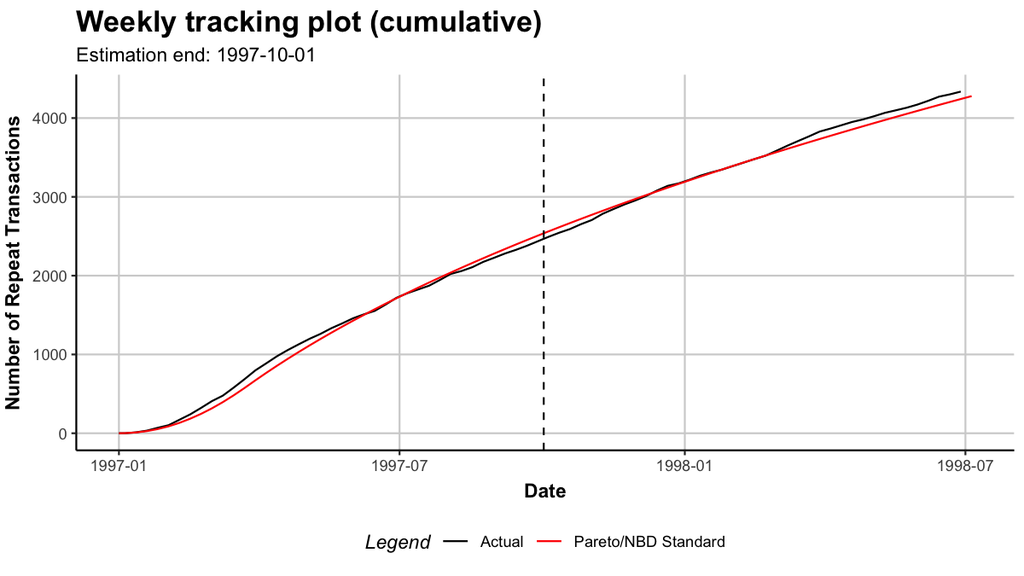

Transacciones acumuladas: reales y Pareto/NBD.

El agregado ajusta muy bien. El gráfico de abajo enseña lo que el agregado esconde.

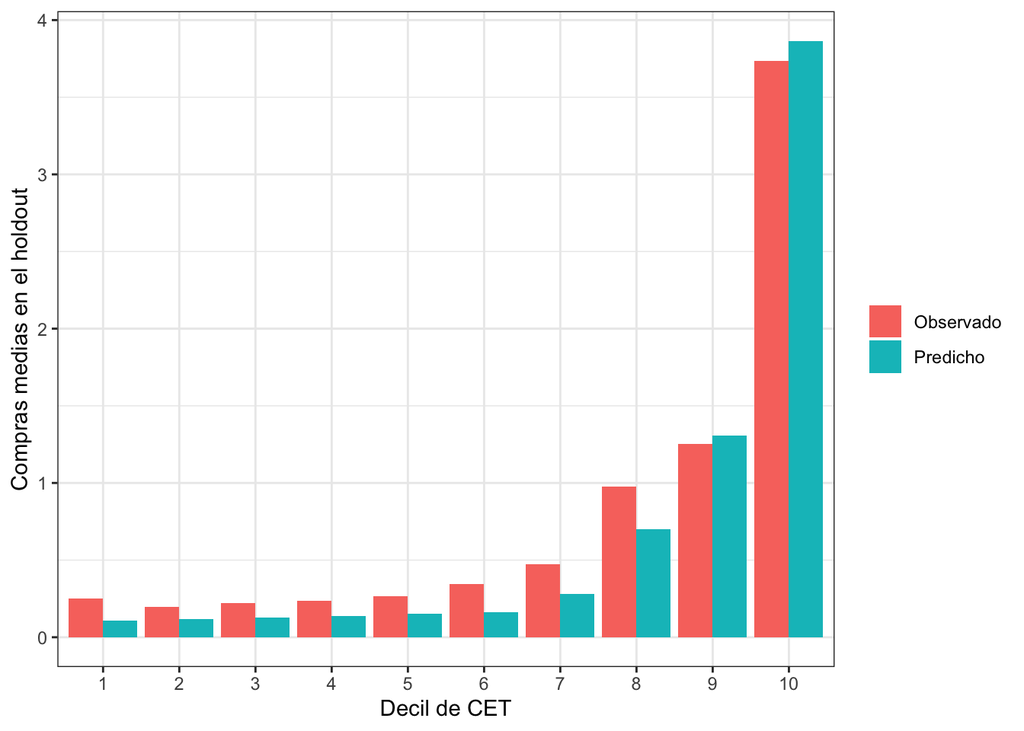

Calibración del Pareto/NBD por deciles de CET.

En los deciles bajos el modelo predice de menos (decil 1: 0.108 frente a 0.251 observado; decil 6: 0.164 frente a 0.343). Arriba calibra bien (decil 9: 1.308 frente a 1.254; decil 10: 3.865 frente a 3.737). La lectura de que el supuesto de homogeneidad no alcanza para la baja actividad es una hipótesis, no un resultado.

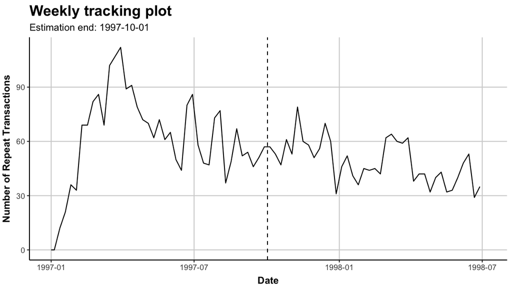

Seguimiento de compras en el tiempo.

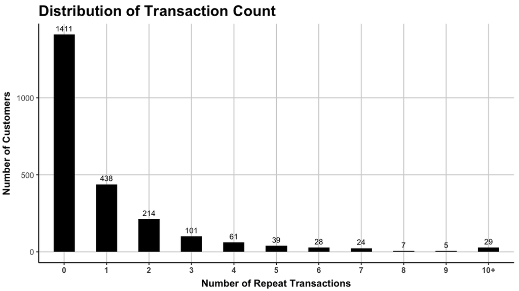

Distribución de la frecuencia de compra.

### 4.3 Benchmark

Mismos clientes y el mismo holdout que los BTYD. XGBoost va con hiperparámetros fijos (`count:poisson`, `eta` 0.05, profundidad 3, 150 rondas, semilla 42): es un baseline justo, no un modelo afinado para ganar.

MAE, RMSE y sesgo en el holdout compartido.

| model | MAE | RMSE | bias |
| --- | --- | --- | --- |
| pnbd | 0.751 | 1.597 | -0.099 |
| ggomnbd | 0.751 | 1.597 | -0.099 |
| bgnbd | 0.782 | 1.602 | -0.101 |
| xgb | 0.908 | 1.677 | 0.002 |
| naive | 1.018 | 2.199 | 0.439 |

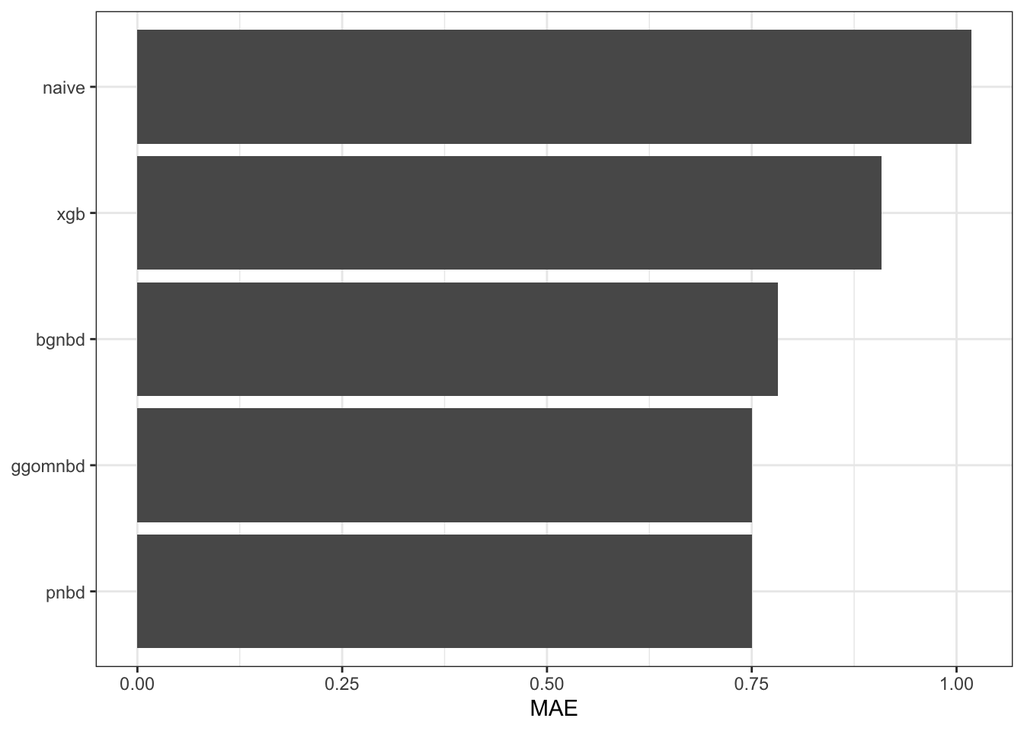

MAE en el holdout. Más bajo es mejor.

XGBoost baja el MAE del baseline un 11% y queda un 21% por encima del Pareto/NBD. El sesgo del árbol es +0.002; el del Pareto/NBD es -0.099. En la referencia de la especificación el MAE de XGBoost era 0.915 (aquí 0.908). El orden no cambia. La diferencia cabe en el binario: R 4.6.0 en macOS arm64 frente a R 4.3.3 en Ubuntu, con la misma versión de xgboost (3.2.1.1) y los mismos hiperparámetros.

## 5 Ventanas móviles

El holdout de 38.7 semanas es uno solo. Para ver si el orden se sostiene, el mismo ejercicio se repite con horizonte fijo de 13 semanas en cuatro cortes de estimación: 26, 39, 52 y 64. El de 39 es el corte del pipeline, pero el horizonte no es el de 38.7 semanas: estos MAE no se comparan con la tabla anterior. El error absoluto baja a medida que la cohorte envejece, porque hay menos compras que errar. Lo que se lee es el orden dentro de cada corte.

MAE en las 13 semanas siguientes a cada corte. 2,357 clientes en todos.

| split_weeks | model | MAE | RMSE | bias | n_customers |
| --- | --- | --- | --- | --- | --- |
| 26 | pnbd | 0.387 | 0.836 | 0.018 | 2357 |
| 26 | bgnbd | 0.390 | 0.829 | 0.002 | 2357 |
| 26 | ggomnbd | 0.387 | 0.836 | 0.018 | 2357 |
| 26 | naive_rate | 0.478 | 1.089 | 0.188 | 2357 |
| 39 | pnbd | 0.339 | 0.755 | -0.043 | 2357 |
| 39 | bgnbd | 0.349 | 0.757 | -0.043 | 2357 |
| 39 | ggomnbd | 0.339 | 0.755 | -0.043 | 2357 |
| 39 | naive_rate | 0.408 | 0.876 | 0.105 | 2357 |
| 52 | pnbd | 0.308 | 0.658 | -0.016 | 2357 |
| 52 | bgnbd | 0.314 | 0.660 | -0.020 | 2357 |
| 52 | ggomnbd | 0.308 | 0.658 | -0.016 | 2357 |
| 52 | naive_rate | 0.364 | 0.746 | 0.104 | 2357 |
| 64 | pnbd | 0.286 | 0.638 | 0.053 | 2357 |
| 64 | bgnbd | 0.287 | 0.639 | 0.048 | 2357 |
| 64 | ggomnbd | 0.286 | 0.638 | 0.053 | 2357 |
| 64 | naive_rate | 0.344 | 0.733 | 0.145 | 2357 |

Media y dispersión del MAE entre los cuatro cortes.

| model | n_origins | MAE_mean | MAE_sd | RMSE_mean | bias_mean |
| --- | --- | --- | --- | --- | --- |
| ggomnbd | 4 | 0.330 | 0.044 | 0.722 | 0.003 |
| pnbd | 4 | 0.330 | 0.044 | 0.722 | 0.003 |
| bgnbd | 4 | 0.335 | 0.045 | 0.721 | -0.003 |
| naive_rate | 4 | 0.398 | 0.059 | 0.861 | 0.135 |

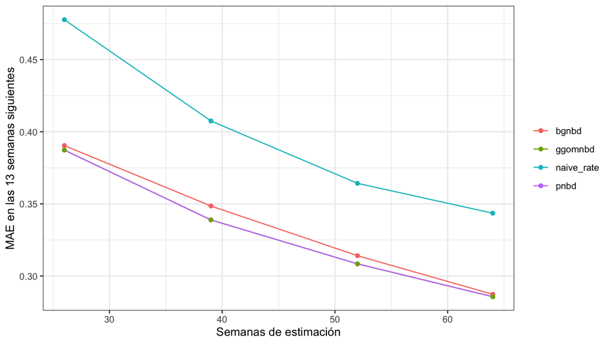

MAE por corte de estimación, horizonte de 13 semanas.

El MAE medio del Pareto/NBD es 0.330 (sd 0.044). El GGom/NBD da 0.330: sigue colapsando al mismo modelo (en los cortes de 26 y 64 el logLik coincide y $b$ es del orden de $10^{-6}$). BG/NBD queda en 0.335 y el baseline en 0.398. En los cuatro cortes los BTYD baten al baseline y el Pareto/NBD queda por debajo de BG/NBD. Esa ventaja media es de unas cinco milésimas de MAE, menor que la dispersión entre cortes. El signo es estable. El tamaño de la ventaja no se separa del calendario.

## 6 Incertidumbre

`predict(..., uncertainty = "boots", level = 0.9)` con 1,000 remuestreos devuelve un intervalo para la media de cada cliente, no para la compra que se va a observar. CLVTools avisa que con menos de 1,000 el percentil es poco estable; el default de la función es 100 y aquí no se usa.

El CET puntual reproduce la calibración del holdout largo. El intervalo es estrecho: la mediana del ancho es 0.047 transacciones, un 32% de la predicción. La estimación puntual cae dentro de su intervalo en el 100% de los clientes. El conteo real del holdout cae dentro en el 2.3%. En los siete deciles bajos la cobertura es cero.

Cobertura del conteo real por el intervalo al 90% de la media.

| bin | n | mean_cet | mean_actual | median_width | coverage |
| --- | --- | --- | --- | --- | --- |
| 1 | 235 | 0.108 | 0.251 | 0.039 | 0.000 |
| 2 | 236 | 0.120 | 0.199 | 0.041 | 0.000 |
| 3 | 236 | 0.129 | 0.220 | 0.043 | 0.000 |
| 4 | 235 | 0.140 | 0.238 | 0.045 | 0.000 |
| 5 | 236 | 0.151 | 0.267 | 0.046 | 0.000 |
| 6 | 236 | 0.164 | 0.343 | 0.048 | 0.000 |
| 7 | 235 | 0.282 | 0.472 | 0.104 | 0.000 |
| 8 | 236 | 0.700 | 0.975 | 0.219 | 0.021 |
| 9 | 236 | 1.308 | 1.254 | 0.317 | 0.127 |
| 10 | 236 | 3.865 | 3.737 | 0.589 | 0.081 |

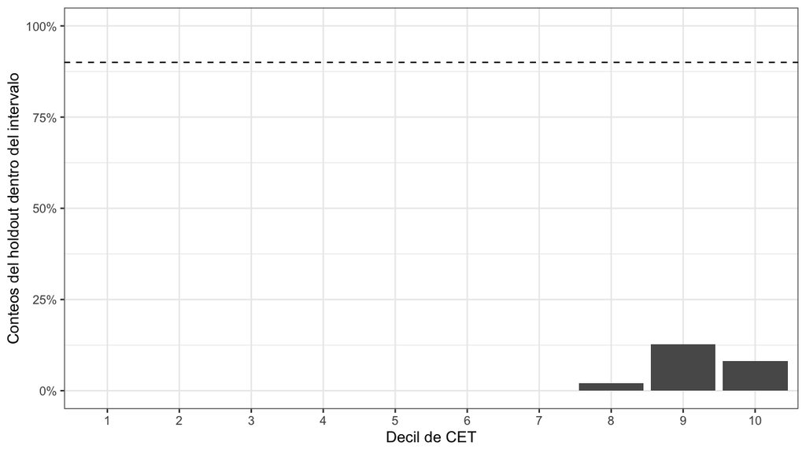

Cobertura del conteo observado. La línea es el 90% de un intervalo de predicción, que esto no es.

En el CLV a 52 semanas y 10% de descuento, la mediana del ancho es un 87% del valor puntual y el punto también cae siempre dentro. El total puntual es 317281, el mismo de la sensibilidad al 10%. Sumar los extremos de cada cliente da 178039 y 439766. Eso no es un intervalo para el total: todos los clientes se mueven con el mismo sorteo de parámetros.

## 7 Sensibilidad y concentración de valor

`predicted.CLV` es DERT por gasto medio, con horizonte infinito. Por eso el total depende de la tasa de descuento y no de `prediction.end`. El horizonte solo mueve `CET` y `predicted.period.spending`. Medir la sensibilidad al horizonte con el CLV habría dado la misma cifra tres veces.

CLV total (horizonte infinito) según la tasa de descuento anual.

| discount | total_CLV |
| --- | --- |
| 0.0 | 455353.7 |
| 0.1 | 317281.2 |
| 0.1 | 254668.0 |
| 0.2 | 217210.3 |

Gasto esperado del período según el horizonte, en semanas.

| horizon_weeks | total_period_spending |
| --- | --- |
| 13 | 22653.7 |
| 26 | 42309.1 |
| 52 | 75712.7 |
| 104 | 128543.9 |

El decil superior de `predicted.CLV` concentra el 61.3% del valor (236 clientes de 2357).

El Gamma/Gamma asume que el gasto medio es independiente de la frecuencia. En los clientes con al menos dos compras durante la estimación, el Spearman entre frecuencia y gasto medio es 0.165. La relación es débil. El supuesto es razonable y no es perfecto.

## 8 Simulación

Se simularon 3,000 clientes desde un Pareto/NBD con parámetros conocidos (orden de magnitud de CDNOW, semilla 42) y se volvió a estimar con el mismo corte de 39 semanas.

Recuperación de parámetros en datos generados por el modelo.

| param | truth | estimate | error % |
| --- | --- | --- | --- |
| r | 0.5530 | 0.5426 | -1.9 |
| alpha | 10.5780 | 10.2643 | -3.0 |
| s | 0.6060 | 0.5155 | -14.9 |
| beta | 11.6690 | 9.7349 | -16.6 |
| E[lambda]=r/alpha | 0.0523 | 0.0529 | 1.1 |
| E[mu]=s/beta | 0.0519 | 0.0530 | 2.0 |

$s$ y $\beta$ se recuperan mal (errores del orden del 15%): están débilmente identificados y se mueven juntos. Las medias $E[\lambda] = r/\alpha$ y $E[\mu] = s/\beta$ vuelven con un error de uno a dos puntos porcentuales. Esa es la comparación que se puede defender.

## 9 Datos reales

Online Retail II (UCI, diciembre de 2009 a diciembre de 2011) no entra en `run_all.R`: el xlsx queda en `data/raw/` y no se versiona. De 1,067,371 líneas se descartan 243,007 sin identificador de cliente, las cantidades o precios no positivos y las facturas que empiezan por C. Una compra es un cliente-día (36,969 facturas se agregan al día). La cohorte son los 1729 clientes cuya primera compra cae en las primeras 13 semanas, de 5878 identificados. La serie sigue hasta la semana 105; para igualar el largo de CDNOW se corta en 78 semanas: estimación de 39 y holdout hasta el 2011-05-31. `EST_SPLIT_WEEKS` no se cambió.

Mismo tipo de error, dos negocios. El MAE por semana evita comparar ventanas de conteo distinto.

| dataset | model | MAE | RMSE | bias | H_weeks | MAE_per_week |
| --- | --- | --- | --- | --- | --- | --- |
| online_retail_ii | bgnbd | 2.026 | 3.353 | 0.210 | 39.000 | 0.052 |
| online_retail_ii | ggomnbd | 2.040 | 3.360 | 0.252 | 39.000 | 0.052 |
| online_retail_ii | pnbd | 2.040 | 3.360 | 0.255 | 39.000 | 0.052 |
| online_retail_ii | naive_rate | 2.041 | 3.450 | 0.238 | 39.000 | 0.052 |
| cdnow | pnbd | 0.751 | 1.597 | -0.099 | 38.857 | 0.019 |
| cdnow | ggomnbd | 0.751 | 1.597 | -0.099 | 38.857 | 0.019 |
| cdnow | bgnbd | 0.782 | 1.602 | -0.101 | 38.857 | 0.020 |
| cdnow | naive_rate | 1.018 | 2.199 | 0.439 | 38.857 | 0.026 |

En CDNOW el mejor modelo le baja al baseline cerca de un cuarto del MAE. Aquí el AIC y el holdout coinciden en BG/NBD, pero el MAE pasa de 2.041 a 2.026: menos de un 1%. El GGom/NBD queda otra vez pegado al Pareto/NBD (`b` = 0.0063).

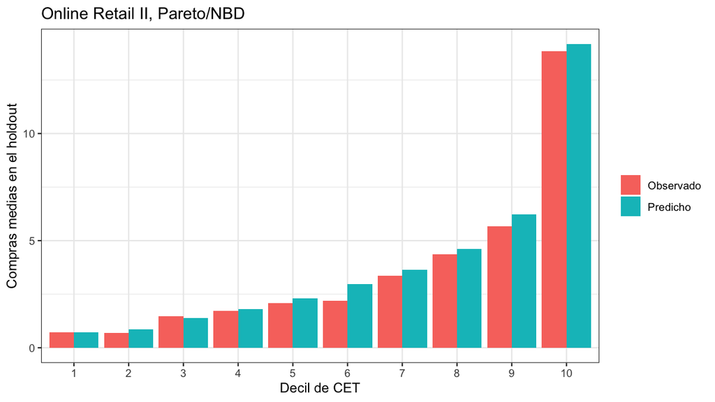

Calibración por deciles en Online Retail II.

El decil 1 predice 0.723 y observa 0.727. No aparece la subestimación de los deciles bajos de CDNOW. El decil superior concentra el 55.3% del CLV, frente al 61.3% de CDNOW. El negocio es estacional y el modelo no tiene calendario: el empate con el baseline es de este corte, no una ley.

## 10 Comercios BNPL

No hay un archivo P13 en esta máquina. El puente usa 2,000 comercios sintéticos del mismo Pareto/NBD, con semilla 42. `Id` es el comercio, `Date` un día con originación y `Price` el monto de esa ocasión. `PAlive` es la probabilidad de seguir originando. No es la probabilidad de que el crédito se pague, y el panel no es una cartera real.

Holdout de los comercios sintéticos.

| model | MAE | RMSE | bias | H_weeks | MAE_per_week |
| --- | --- | --- | --- | --- | --- |
| pnbd | 0.716 | 1.393 | 0.074 | 39 | 0.018 |
| ggomnbd | 0.716 | 1.393 | 0.074 | 39 | 0.018 |
| bgnbd | 0.747 | 1.390 | 0.076 | 39 | 0.019 |
| naive_rate | 0.913 | 1.858 | 0.496 | 39 | 0.023 |

El Pareto/NBD baja el MAE del baseline de 0.913 a 0.716. Cuando los datos salen del modelo, la ventaja reaparece; en Online Retail II casi no estaba. Los comercios con `PAlive` menor que 0.5 originan en el holdout 0.15 veces de media, y los que están por encima originan 2.39. El 73.2% queda por debajo de 0.5. En el decil de mayor monto originado durante la estimación, esa fracción es 13.5%: el volumen está concentrado en comercios que el modelo todavía da por activos.

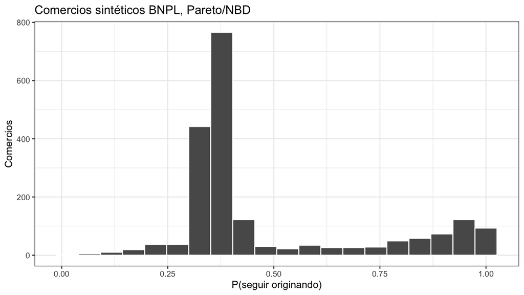

Probabilidad de seguir originando.

## 11 Cuántos comercios hacen falta

Diez semillas por tamaño. El error es el de la media implícita.

| n | param | n_ok | mediana \|error\| % |
| --- | --- | --- | --- |
| 500 | E[lambda] | 9 | 7.9 |
| 1000 | E[lambda] | 8 | 10.9 |
| 2000 | E[lambda] | 10 | 4.5 |
| 3000 | E[lambda] | 10 | 4.3 |
| 5000 | E[lambda] | 10 | 3.8 |
| 500 | E[mu] | 9 | 42.6 |
| 1000 | E[mu] | 8 | 42.1 |
| 2000 | E[mu] | 10 | 25.2 |
| 3000 | E[mu] | 10 | 16.8 |
| 5000 | E[mu] | 10 | 14.1 |

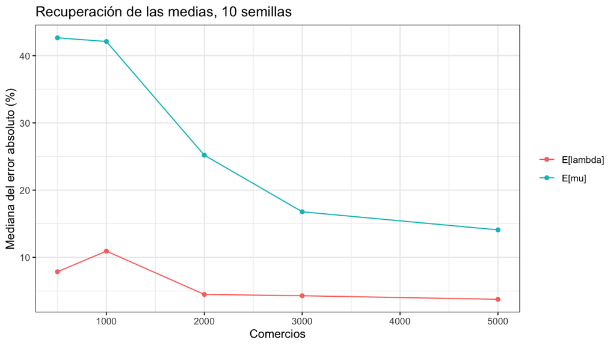

Mediana del error absoluto según el número de comercios.

## 12 El abandono pide más muestra

La grilla anterior paraba en 5,000. Antes de volver a mirar el resultado se alargó a 10,000 y 20,000, con las mismas semillas 1 a 10. Los tamaños de 500 a 5,000 reproducen la mediana ya publicada (diferencia numérica de orden (10^{-16})).

Error mediano en 5,000 y 20,000 comercios.

| n | param | n_ok | mediana \|error\| % |
| --- | --- | --- | --- |
| 5000 | E[lambda] | 10 | 3.8 |
| 20000 | E[lambda] | 10 | 1.9 |
| 5000 | E[mu] | 10 | 14.1 |
| 20000 | E[mu] | 10 | 4.9 |
| 5000 | beta | 10 | 28.3 |
| 20000 | beta | 10 | 11.8 |
| 5000 | s | 10 | 16.5 |
| 20000 | s | 10 | 8.0 |

Correlación, entre semillas, de las estimaciones de s y beta.

| n | n_ok | cor_s_beta |
| --- | --- | --- |
| 500 | 9 | 0.923 |
| 1000 | 8 | 0.999 |
| 2000 | 10 | 0.998 |
| 3000 | 10 | 0.976 |
| 5000 | 10 | 0.930 |
| 10000 | 10 | 0.992 |
| 20000 | 10 | 0.984 |

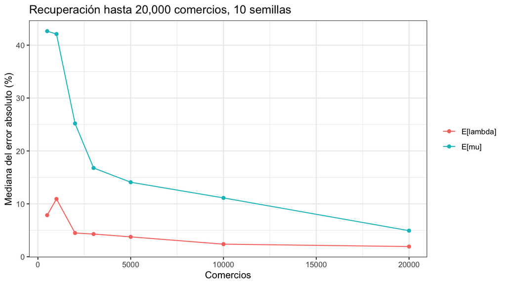

La tasa de abandono sigue bajando después de 5,000 comercios.

## 13 Estacionalidad

La hipótesis, escrita antes de mirar el error, era esta: en las cuatro semanas de diciembre de 2010, repetir las cuatro semanas de diciembre de 2009 empata o gana a los BTYD; en las cuatro semanas de junio de 2011, los BTYD bajan el MAE de la tasa histórica. Misma cohorte y mismo corte de 39 semanas. Diciembre sí está más activo que junio: 0.411 ocasiones de media frente a 0.308.

MAE en dos ventanas de cuatro semanas.

| window | model | MAE | bias | mean_actual |
| --- | --- | --- | --- | --- |
| diciembre | naive_rate | 0.413 | -0.016 | 0.411 |
| diciembre | bgnbd | 0.436 | -0.019 | 0.411 |
| diciembre | ggomnbd | 0.439 | -0.014 | 0.411 |
| diciembre | pnbd | 0.439 | -0.014 | 0.411 |
| diciembre | seasonal | 0.626 | 0.376 | 0.411 |
| junio | naive_rate | 0.371 | 0.087 | 0.308 |
| junio | bgnbd | 0.386 | 0.082 | 0.308 |
| junio | ggomnbd | 0.389 | 0.087 | 0.308 |
| junio | pnbd | 0.390 | 0.088 | 0.308 |
| junio | seasonal | 0.390 | 0.106 | 0.308 |

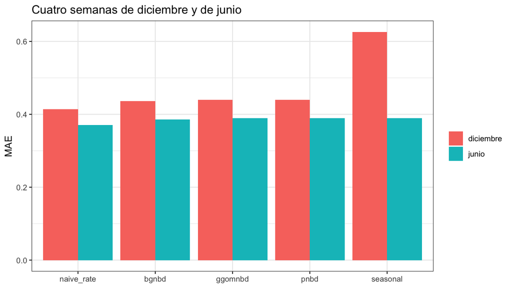

Diciembre y junio, mismos modelos.

La hipótesis no se sostiene. En diciembre el peor modelo es el estacional (MAE 0.626), con sesgo positivo: el primer diciembre de la cohorte es cuando el cliente entra, y eso no se repite. En las dos ventanas gana la tasa histórica, y el BG/NBD queda un poco por encima (0.436 en diciembre y 0.386 en junio). El empate del holdout largo no era solo Navidad.

## 14 Quién compra

El MAE de cuatro semanas deja a la mayoría en cero: compra el 27.2% en diciembre y el 22.8% en junio. La hipótesis, fijada antes de mirar el resultado, era que ahí el Spearman del BG/NBD y del Pareto/NBD superaba al de la tasa histórica.

Spearman con el conteo observado. Repetidores: al menos dos compras en la estimación.

| window | model | spearman_all | spearman_repeat |
| --- | --- | --- | --- |
| diciembre | naive_rate | 0.451 | 0.408 |
| diciembre | pnbd | 0.448 | 0.410 |
| diciembre | ggomnbd | 0.448 | 0.410 |
| diciembre | bgnbd | 0.448 | 0.409 |
| diciembre | seasonal | 0.358 | 0.371 |
| junio | naive_rate | 0.413 | 0.368 |
| junio | bgnbd | 0.412 | 0.372 |
| junio | pnbd | 0.411 | 0.370 |
| junio | ggomnbd | 0.411 | 0.370 |
| junio | seasonal | 0.321 | 0.276 |

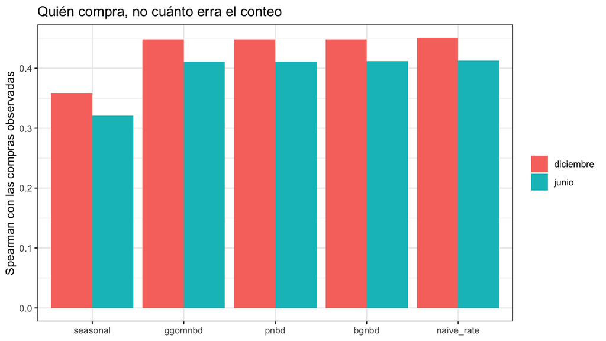

Orden de quién compra.

No se sostiene en la cohorte completa. En diciembre la tasa queda en 0.451 y el Pareto/NBD en 0.448. En junio, 0.413 y 0.412. Entre quienes ya repitieron en la estimación la diferencia cambia de signo y sigue en el tercer decimal (0.410 frente a 0.408 en diciembre). El modelo no ordena mejor quién va a comprar en estas ventanas.

## 15 Orden en el holdout largo

Las cuatro semanas no separaron el orden. La hipótesis para el holdout de 39 semanas, la misma cohorte de la fase de Online Retail, era que el Spearman y la captura del decil superior del Pareto/NBD y del BG/NBD superaban a la tasa histórica.

Holdout de 39 semanas. El decil es la parte de las compras futuras que cae en el 10% con mayor pronóstico.

| model | spearman | decil % | MAE |
| --- | --- | --- | --- |
| naive_rate | 0.655 | 38.2 | 2.041 |
| bgnbd | 0.655 | 38.3 | 2.026 |
| ggomnbd | 0.652 | 38.3 | 2.040 |
| pnbd | 0.652 | 38.3 | 2.040 |

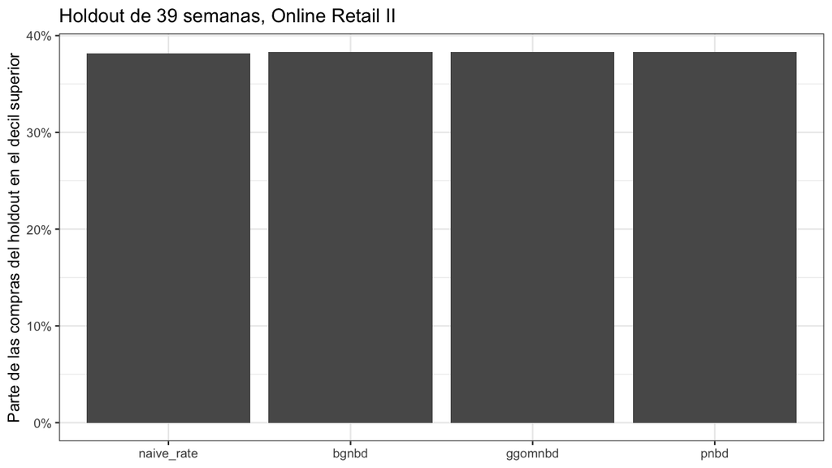

Concentración de las compras futuras.

Tampoco. El Spearman es 0.655 para la tasa y 0.655 para el BG/NBD. El decil superior se queda con el 38.2% de las compras si se ordena por la tasa, y con el 38.3% si se ordena por el BG/NBD. El MAE reproduce el de la fase anterior (2.026 frente a 2.041): la pequeña ventaja de error no trae un mejor orden.

## 16 Dónde falla la tasa

La hipótesis, fijada antes de mirar el error, era que con una sola compra en la estimación los BTYD bajan el MAE de la tasa, y que con seis o más la tasa empata o gana. Tramos: 1, 2, 3 a 5, y 6 o más. Mismo corte de 39 semanas en los dos datasets.

MAE según las ocasiones observadas antes del corte.

| dataset | bin | model | n_customers | mean_actual | mean_pred | MAE |
| --- | --- | --- | --- | --- | --- | --- |
| cdnow | 1 | naive_rate | 1411 | 0.237 | 0.000 | 0.237 |
| cdnow | 1 | pnbd | 1411 | 0.237 | 0.136 | 0.334 |
| cdnow | 1 | bgnbd | 1411 | 0.237 | 0.223 | 0.398 |
| cdnow | 2 | bgnbd | 438 | 0.696 | 0.519 | 0.798 |
| cdnow | 2 | pnbd | 438 | 0.696 | 0.589 | 0.803 |
| cdnow | 2 | naive_rate | 438 | 0.696 | 1.195 | 1.106 |
| cdnow | 3-5 | bgnbd | 376 | 1.620 | 1.339 | 1.337 |
| cdnow | 3-5 | pnbd | 376 | 1.620 | 1.506 | 1.366 |
| cdnow | 3-5 | naive_rate | 376 | 1.620 | 3.096 | 2.172 |
| cdnow | 6+ | bgnbd | 132 | 4.765 | 4.496 | 3.256 |
| cdnow | 6+ | pnbd | 132 | 4.765 | 4.750 | 3.270 |
| cdnow | 6+ | naive_rate | 132 | 4.765 | 9.279 | 5.789 |
| online_retail_ii | 1 | naive_rate | 388 | 0.706 | 0.000 | 0.706 |
| online_retail_ii | 1 | pnbd | 388 | 0.706 | 0.811 | 0.853 |
| online_retail_ii | 1 | bgnbd | 388 | 0.706 | 0.813 | 0.853 |
| online_retail_ii | 2 | naive_rate | 349 | 1.768 | 1.182 | 1.334 |
| online_retail_ii | 2 | bgnbd | 349 | 1.768 | 1.585 | 1.357 |
| online_retail_ii | 2 | pnbd | 349 | 1.768 | 1.729 | 1.378 |
| online_retail_ii | 3-5 | naive_rate | 584 | 2.896 | 3.207 | 1.828 |
| online_retail_ii | 3-5 | bgnbd | 584 | 2.896 | 3.281 | 1.850 |
| online_retail_ii | 3-5 | pnbd | 584 | 2.896 | 3.324 | 1.867 |
| online_retail_ii | 6+ | bgnbd | 408 | 8.990 | 9.384 | 3.968 |
| online_retail_ii | 6+ | pnbd | 408 | 8.990 | 9.390 | 3.981 |
| online_retail_ii | 6+ | naive_rate | 408 | 8.990 | 10.725 | 4.222 |

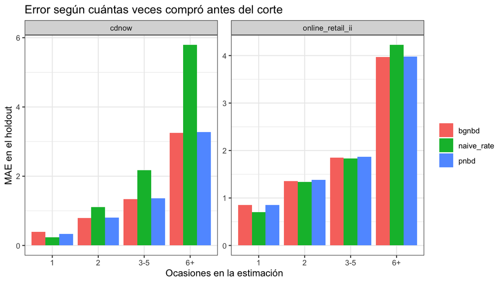

Error por tramo de frecuencia.

La hipótesis sale al revés en los dos negocios. Con una sola compra, predecir cero gana: en CDNOW el MAE es 0.237 para la tasa y 0.334 para el Pareto/NBD; en Online Retail, 0.706 y 0.853. El modelo les asigna a todos una compra futura pequeña, y la mayoría no vuelve. Con seis o más compras la tasa se dispara (en CDNOW predice 9.28 donde se observan 4.77) y ahí los BTYD bajan el error. En el minorista ese exceso es menor, por eso el agregado casi empata.

## 17 Denominador corto

La hipótesis era que el exceso de la tasa, en el tramo de seis o más compras, estaba en quienes hicieron la primera compra en la segunda mitad de las 39 semanas, y que usar siempre 39 como denominador acercaba ese MAE al BG/NBD. En la primera mitad, las dos tasas debían parecerse.

Ese tramo tardío no existe. Los 132 clientes de CDNOW y los 408 del minorista con seis o más compras empezaron todos en la primera mitad. No hay a quién echarle la culpa de un denominador de unas pocas semanas.

Seis o más compras, primera mitad de la ventana. naive_calendar divide entre 39 semanas.

| dataset | model | n_customers | mean_actual | mean_pred | MAE |
| --- | --- | --- | --- | --- | --- |
| cdnow | bgnbd | 132 | 4.77 | 4.50 | 3.256 |
| cdnow | pnbd | 132 | 4.77 | 4.75 | 3.270 |
| cdnow | naive_calendar | 132 | 4.77 | 7.92 | 4.968 |
| cdnow | naive_rate | 132 | 4.77 | 9.28 | 5.789 |
| online_retail_ii | naive_calendar | 408 | 8.99 | 10.17 | 3.961 |
| online_retail_ii | bgnbd | 408 | 8.99 | 9.38 | 3.968 |
| online_retail_ii | pnbd | 408 | 8.99 | 9.39 | 3.981 |
| online_retail_ii | naive_rate | 408 | 8.99 | 10.73 | 4.222 |

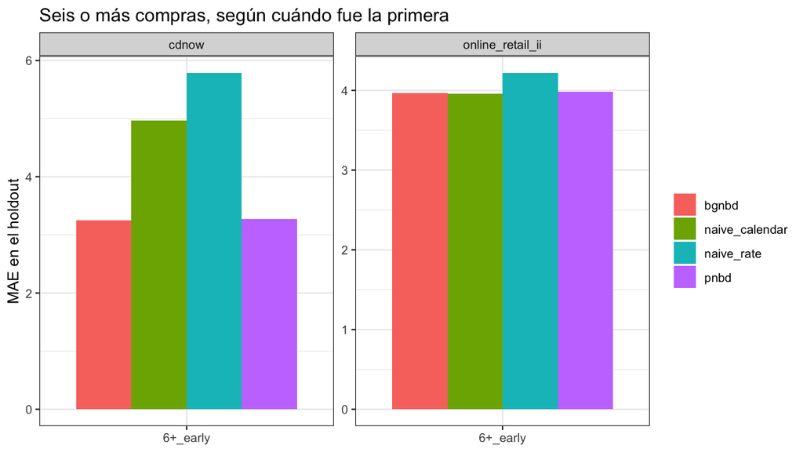

Tasa individual, tasa sobre 39 semanas y BTYD.

En CDNOW, alargar el denominador baja el pronóstico de 9.28 a 7.92, frente a 4.77 observado y 4.50 del BG/NBD. Cierra una parte y deja el MAE en 4.97, lejos del 3.26 del modelo. En el minorista las tres cifras ya estaban juntas: la tasa sobre 39 semanas tiene MAE 3.961 y el BG/NBD 3.968. El exceso que queda en CDNOW no es un denominador corto.

## 18 Última compra

La hipótesis, fijada antes de mirar el error, era que ese exceso está en quienes tienen seis o más compras y no vuelven a comprar desde la primera mitad de las 39 semanas. Ahí el BG/NBD debía bajar el MAE de la tasa sobre 39 semanas. Quienes compran en la segunda mitad siguen activos, y ahí esa tasa debía empatar o ganar.

Seis o más compras. silent: última compra antes de la semana 19.5. recent: desde esa semana. naive_calendar divide entre 39.

| dataset | cell | model | n_customers | mean_last_wk | mean_actual | mean_pred | MAE | mean_palive |
| --- | --- | --- | --- | --- | --- | --- | --- | --- |
| cdnow | 6+_silent | pnbd | 8 | 13.3 | 1.50 | 0.34 | 1.172 | 0.084 |
| cdnow | 6+_silent | bgnbd | 8 | 13.3 | 1.50 | 0.23 | 1.272 | 0.054 |
| cdnow | 6+_silent | naive_calendar | 8 | 13.3 | 1.50 | 7.47 | 5.973 | NA |
| cdnow | 6+_silent | naive_rate | 8 | 13.3 | 1.50 | 8.66 | 7.163 | NA |
| cdnow | 6+_recent | bgnbd | 124 | 33.6 | 4.98 | 4.77 | 3.384 | 0.721 |
| cdnow | 6+_recent | pnbd | 124 | 33.6 | 4.98 | 5.03 | 3.405 | 0.816 |
| cdnow | 6+_recent | naive_calendar | 124 | 33.6 | 4.98 | 7.95 | 4.903 | NA |
| cdnow | 6+_recent | naive_rate | 124 | 33.6 | 4.98 | 9.32 | 5.700 | NA |
| online_retail_ii | 6+_silent | bgnbd | 5 | 14.8 | 1.40 | 4.04 | 3.222 | 0.706 |
| online_retail_ii | 6+_silent | pnbd | 5 | 14.8 | 1.40 | 4.93 | 3.979 | 0.862 |
| online_retail_ii | 6+_silent | naive_calendar | 5 | 14.8 | 1.40 | 5.80 | 4.800 | NA |
| online_retail_ii | 6+_silent | naive_rate | 5 | 14.8 | 1.40 | 6.17 | 5.048 | NA |
| online_retail_ii | 6+_recent | naive_calendar | 403 | 35.6 | 9.08 | 10.22 | 3.950 | NA |
| online_retail_ii | 6+_recent | bgnbd | 403 | 35.6 | 9.08 | 9.45 | 3.977 | 0.996 |
| online_retail_ii | 6+_recent | pnbd | 403 | 35.6 | 9.08 | 9.45 | 3.981 | 0.999 |
| online_retail_ii | 6+_recent | naive_rate | 403 | 35.6 | 9.08 | 10.78 | 4.211 | NA |

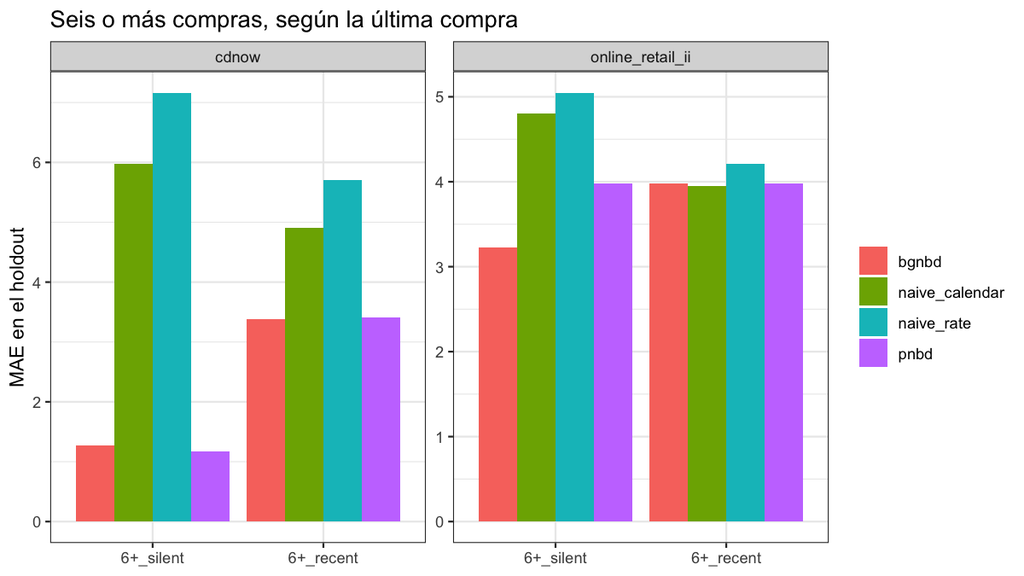

Seis o más compras, según la última compra.

En CDNOW la hipótesis no se sostiene. La segunda mitad es 124 de los 132 clientes. Su última compra cae en la semana 33.6 y la P(activo) del BG/NBD es 0.72. La tasa sobre 39 semanas predice 7.95 donde se observan 4.98 (MAE 4.90). El BG/NBD predice 4.77 (MAE 3.38). El exceso sigue en clientes a los que el modelo da por activos.

Los 8 restantes tienen la última compra en la semana 13.3 y una P(activo) de 0.05. La tasa predice 7.47 y se observan 1.50. El BG/NBD baja a 0.23. Es la celda que la hipótesis pedía, y no alcanza para el exceso del tramo.

En el minorista, 403 de 408 siguen comprando en la segunda mitad, con P(activo) 0.996. El MAE de la tasa sobre 39 semanas es 3.95 y el del BG/NBD 3.98. Ahí la tasa empata, en el dataset donde el tramo completo ya empataba.

## 19 Mitad rápida

La hipótesis, fijada antes de mirar el error, parte a esos compradores recientes con seis o más compras por la mediana de su tasa `(n-1)/edad`. En las dos mitades el BG/NBD debía predecir menos que la tasa sobre 39 semanas, y el exceso de esa tasa debía ser mayor en la mitad alta. En esa mitad, multiplicar la tasa por la P(activo) del BG/NBD debía dejar la media por encima de la predicción del modelo.

Recientes con seis o más compras. La mediana de (n-1)/edad separa las mitades. calendar_x_bgnbd multiplica la tasa de 39 semanas por la P(activo). bias es predicción media menos observado.

| dataset | cell | model | n_customers | mean_actual | mean_pred | bias | MAE | mean_palive |
| --- | --- | --- | --- | --- | --- | --- | --- | --- |
| cdnow | recent_low | naive_calendar | 62 | 3.68 | 5.53 | 1.85 | 4.09 | NA |
| cdnow | recent_low | calendar_x_bgnbd | 62 | 3.68 | 3.79 | 0.11 | 3.00 | 0.688 |
| cdnow | recent_low | calendar_x_pnbd | 62 | 3.68 | 4.37 | 0.69 | 3.20 | 0.794 |
| cdnow | recent_low | bgnbd | 62 | 3.68 | 3.17 | -0.51 | 2.94 | 0.688 |
| cdnow | recent_low | pnbd | 62 | 3.68 | 3.45 | -0.23 | 2.98 | 0.794 |
| cdnow | recent_high | naive_calendar | 62 | 6.27 | 10.37 | 4.09 | 5.72 | NA |
| cdnow | recent_high | calendar_x_bgnbd | 62 | 6.27 | 7.86 | 1.58 | 4.39 | 0.755 |
| cdnow | recent_high | calendar_x_pnbd | 62 | 6.27 | 8.66 | 2.39 | 4.70 | 0.839 |
| cdnow | recent_high | bgnbd | 62 | 6.27 | 6.38 | 0.10 | 3.83 | 0.755 |
| cdnow | recent_high | pnbd | 62 | 6.27 | 6.62 | 0.35 | 3.83 | 0.839 |
| online_retail_ii | recent_low | naive_calendar | 201 | 5.32 | 5.74 | 0.42 | 2.50 | NA |
| online_retail_ii | recent_low | calendar_x_bgnbd | 201 | 5.32 | 5.71 | 0.39 | 2.49 | 0.995 |
| online_retail_ii | recent_low | calendar_x_pnbd | 201 | 5.32 | 5.73 | 0.41 | 2.50 | 0.999 |
| online_retail_ii | recent_low | bgnbd | 201 | 5.32 | 5.68 | 0.36 | 2.57 | 0.995 |
| online_retail_ii | recent_low | pnbd | 201 | 5.32 | 5.69 | 0.37 | 2.57 | 0.999 |
| online_retail_ii | recent_high | naive_calendar | 202 | 12.83 | 14.68 | 1.85 | 5.40 | NA |
| online_retail_ii | recent_high | calendar_x_bgnbd | 202 | 12.83 | 14.65 | 1.82 | 5.39 | 0.997 |
| online_retail_ii | recent_high | calendar_x_pnbd | 202 | 12.83 | 14.67 | 1.84 | 5.39 | 0.999 |
| online_retail_ii | recent_high | bgnbd | 202 | 12.83 | 13.20 | 0.37 | 5.38 | 0.997 |
| online_retail_ii | recent_high | pnbd | 202 | 12.83 | 13.19 | 0.35 | 5.38 | 0.999 |

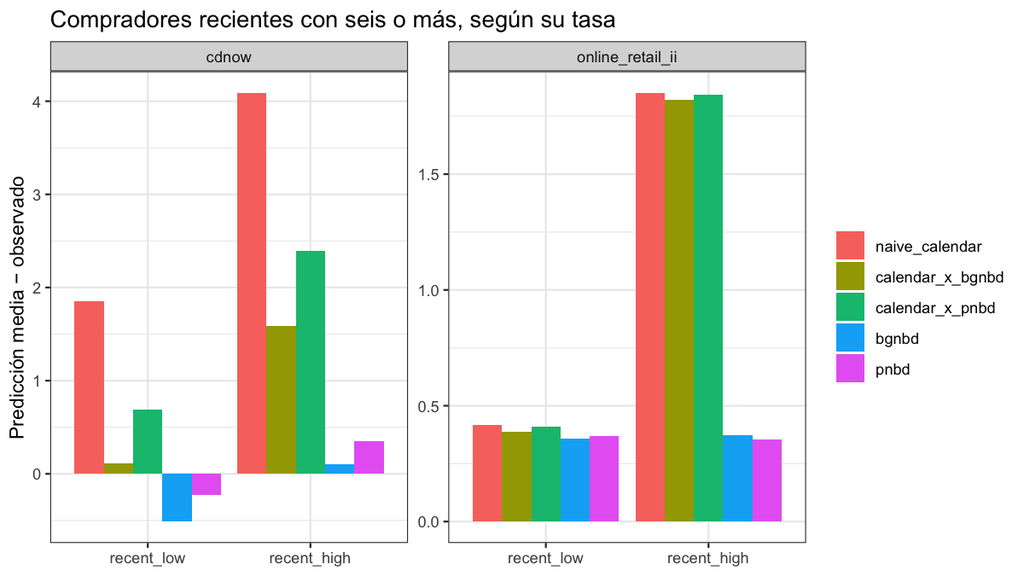

Exceso de la predicción en las dos mitades de la tasa.

La hipótesis se sostiene. En CDNOW cada mitad tiene 62 clientes. En la alta, la tasa predice 10.37 y se observan 6.27 (exceso 4.09). Multiplicar por la P(activo) baja la media a 7.86. El BG/NBD llega a 6.38 y el Pareto/NBD a 6.62. En la baja, la tasa predice 5.53 (exceso 1.85, menor que en la alta). La P(activo) deja 3.79 frente a 3.68 observado, y el BG/NBD sigue hasta 3.17.

Las 124 personas juntas reproducen el corte anterior: la tasa predice 7.95, la tasa por la P(activo) 5.82 y el BG/NBD 4.77, con 4.98 observado.

En el minorista la P(activo) de la mitad alta es 0.997, así que multiplicar por ella mueve la tasa de 14.68 a 14.65. El BG/NBD baja a 13.20, con 12.83 observado. En la mitad baja las tres medias quedan entre 5.68 y 5.74, y lo observado es 5.32. El exceso de la tasa es 1.85 arriba y 0.42 abajo.

## 20 Quien vuelve

La hipótesis, fijada antes de mirar el error, decía que el exceso de la mitad rápida desaparece al dejar solo a quienes compran al menos una vez en el holdout. En ese grupo la media de la tasa sobre 39 semanas debía quedar por debajo o al lado de lo observado, y el BG/NBD por debajo de la tasa. Es una descomposición: el modelo no sabía quién iba a volver.

active: al menos una compra en el holdout. n_parent es el tamaño de la mitad antes de ese filtro.

| dataset | cell | subset | model | n_customers | n_parent | mean_actual | mean_pred | bias | MAE |
| --- | --- | --- | --- | --- | --- | --- | --- | --- | --- |
| cdnow | recent_low | all | naive_calendar | 62 | 62 | 3.68 | 5.53 | 1.85 | 4.09 |
| cdnow | recent_low | all | bgnbd | 62 | 62 | 3.68 | 3.17 | -0.51 | 2.94 |
| cdnow | recent_low | all | pnbd | 62 | 62 | 3.68 | 3.45 | -0.23 | 2.98 |
| cdnow | recent_low | active | naive_calendar | 43 | 62 | 5.30 | 5.61 | 0.30 | 3.53 |
| cdnow | recent_low | active | bgnbd | 43 | 62 | 5.30 | 3.36 | -1.94 | 3.03 |
| cdnow | recent_low | active | pnbd | 43 | 62 | 5.30 | 3.63 | -1.67 | 2.96 |
| cdnow | recent_high | all | naive_calendar | 62 | 62 | 6.27 | 10.37 | 4.09 | 5.72 |
| cdnow | recent_high | all | bgnbd | 62 | 62 | 6.27 | 6.38 | 0.10 | 3.83 |
| cdnow | recent_high | all | pnbd | 62 | 62 | 6.27 | 6.62 | 0.35 | 3.83 |
| cdnow | recent_high | active | naive_calendar | 53 | 62 | 7.34 | 10.72 | 3.38 | 5.28 |
| cdnow | recent_high | active | bgnbd | 53 | 62 | 7.34 | 6.73 | -0.61 | 3.75 |
| cdnow | recent_high | active | pnbd | 53 | 62 | 7.34 | 6.94 | -0.40 | 3.68 |
| online_retail_ii | recent_low | all | naive_calendar | 201 | 201 | 5.32 | 5.74 | 0.42 | 2.50 |
| online_retail_ii | recent_low | all | bgnbd | 201 | 201 | 5.32 | 5.68 | 0.36 | 2.57 |
| online_retail_ii | recent_low | all | pnbd | 201 | 201 | 5.32 | 5.69 | 0.37 | 2.57 |
| online_retail_ii | recent_low | active | naive_calendar | 192 | 201 | 5.57 | 5.74 | 0.17 | 2.35 |
| online_retail_ii | recent_low | active | bgnbd | 192 | 201 | 5.57 | 5.66 | 0.09 | 2.40 |
| online_retail_ii | recent_low | active | pnbd | 192 | 201 | 5.57 | 5.66 | 0.10 | 2.41 |
| online_retail_ii | recent_high | all | naive_calendar | 202 | 202 | 12.83 | 14.68 | 1.85 | 5.40 |
| online_retail_ii | recent_high | all | bgnbd | 202 | 202 | 12.83 | 13.20 | 0.37 | 5.38 |
| online_retail_ii | recent_high | all | pnbd | 202 | 202 | 12.83 | 13.19 | 0.35 | 5.38 |
| online_retail_ii | recent_high | active | naive_calendar | 195 | 202 | 13.29 | 14.84 | 1.55 | 5.22 |
| online_retail_ii | recent_high | active | bgnbd | 195 | 202 | 13.29 | 13.33 | 0.04 | 5.22 |
| online_retail_ii | recent_high | active | pnbd | 195 | 202 | 13.29 | 13.31 | 0.02 | 5.22 |

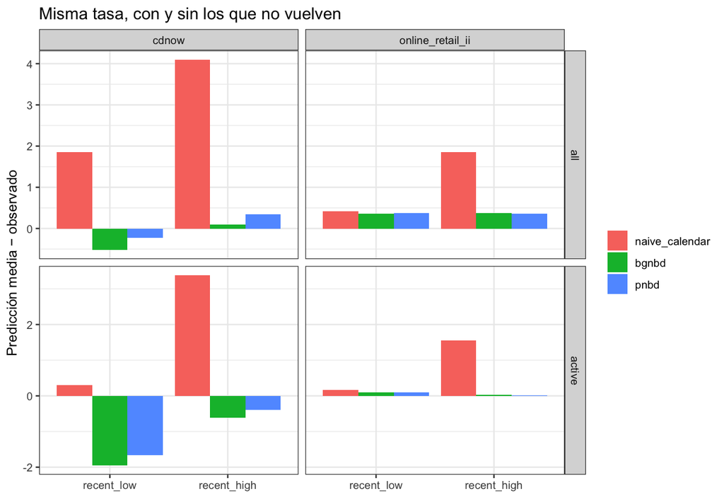

Exceso con todos y solo con quienes vuelven.

La hipótesis no se sostiene en la mitad rápida. En CDNOW vuelven 53 de 62. La tasa predice 10.72 y se observan 7.34 (exceso 3.38, frente a 4.09 con los 62). El BG/NBD queda en 6.73 y el Pareto/NBD en 6.94.

En la mitad lenta de CDNOW vuelven 43 de 62. Ahí la tasa queda en 5.61 frente a 5.30 (exceso 0.30, y era 1.85 con todos). El BG/NBD baja a 3.36.

En el minorista vuelven 195 de 202 en la mitad rápida. La tasa predice 14.84, el BG/NBD 13.33 y se observan 13.29. El conjunto de las 124 personas de CDNOW, sin filtrar, reproduce el corte anterior: tasa 7.95, BG/NBD 4.77, observado 4.98.

## 21 Ritmo

La hipótesis, fijada antes de mirar el intervalo, decía que en la mitad rápida quienes compran al menos dos veces en el holdout no se vuelven más lentos. La mediana del intervalo entre la primera y la última compra del holdout, menos el mismo intervalo en la estimación, debía ser menor o igual que cero. El silencio después de la última compra no entra en esa cuenta.

Al menos dos compras en el holdout. El intervalo es el tiempo entre la primera y la última, dividido por las compras menos una. median_gap_diff está en semanas.

| dataset | cell | n_customers | median_est_gap | median_hold_gap | median_gap_diff | share_slower | mean_actual | mean_calendar | mean_bgnbd |
| --- | --- | --- | --- | --- | --- | --- | --- | --- | --- |
| cdnow | recent_low | 34 | 5.42 | 5.00 | -0.39 | 0.47 | 6.44 | 5.57 | 3.54 |
| cdnow | recent_high | 47 | 3.17 | 3.81 | 0.93 | 0.72 | 8.15 | 11.11 | 7.07 |
| online_retail_ii | recent_low | 180 | 5.67 | 6.17 | 0.73 | 0.57 | 5.87 | 5.78 | 5.67 |
| online_retail_ii | recent_high | 186 | 3.10 | 3.26 | 0.35 | 0.67 | 13.89 | 15.03 | 13.47 |

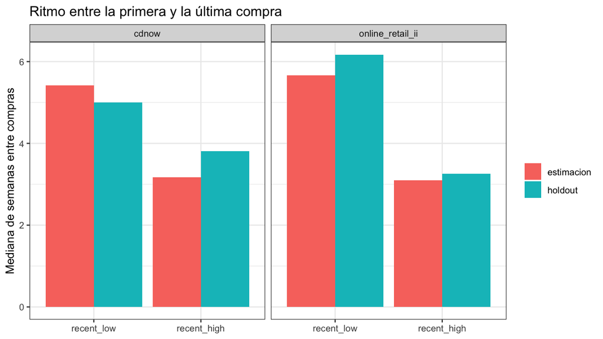

Semanas entre compras, antes del corte y en el holdout.

La hipótesis no se sostiene. En la mitad rápida de CDNOW hay 47 clientes con al menos dos compras, de los 53 que vuelven. La mediana pasa de 3.17 semanas entre compras a 3.81 (diferencia 0.93). El 72% se vuelve más lento. La media del holdout sube a 5.33 porque algunos intervalos son largos. En ese grupo la tasa predice 11.11 y se observan 8.15. El BG/NBD queda en 7.07.

En la mitad lenta la mediana no se alarga: de 5.42 a 5.00. La tasa predice 5.57 y se observan 6.44. Los 6 que compran una sola vez en la mitad rápida predicen 7.64 y compran 1. Son pocos al lado de los 47.

En el minorista la mitad rápida también alarga el intervalo, de 3.10 a 3.26 semanas (67% más lentos). La tasa predice 15.03, el BG/NBD 13.47 y se observan 13.89. Quienes vuelven en CDNOW, sin pedirles dos compras, reproducen el corte anterior: 53 clientes, tasa 10.72, observado 7.34.

## 22 Antes del corte

La hipótesis, fijada antes de mirar el intervalo, decía que esos clientes de la mitad rápida ya no se estaban frenando antes del corte. En la estimación, la mediana de (intervalo de la segunda mitad − intervalo de la primera), cliente por cliente, debía ser menor o igual que cero. Si el número de intervalos es impar, el del centro no entra.

Al menos dos compras en el holdout. median_diff es el cambio, en semanas, de la primera mitad de la estimación a la segunda.

| dataset | cell | n_customers | median_early | median_late | median_diff | share_slower |
| --- | --- | --- | --- | --- | --- | --- |
| cdnow | recent_low | 34 | 4.11 | 5.07 | -0.10 | 0.50 |
| cdnow | recent_high | 47 | 2.14 | 3.14 | 0.45 | 0.64 |
| online_retail_ii | recent_low | 180 | 5.33 | 5.69 | 0.38 | 0.53 |
| online_retail_ii | recent_high | 186 | 2.91 | 2.73 | -0.09 | 0.47 |

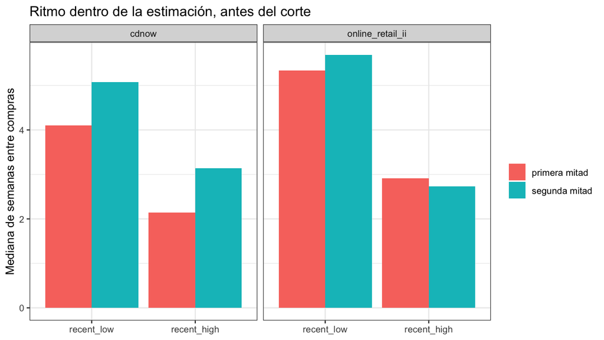

Ritmo en la primera y en la segunda mitad de la estimación.

En CDNOW la hipótesis no se sostiene. En los 47 la mediana del cambio es 0.45 semanas: la primera mitad queda en 2.14 y la segunda en 3.14. El 64% se vuelve más lento. Los 62 de la mitad rápida, sin pedirles dos compras después, tienen una mediana de 0.71 y el 71% se vuelve más lento. Es el mismo grupo que el corte anterior: la tasa predice 11.11 y se observan 8.15.

En la mitad lenta, los 34 tienen una mediana de -0.10 y el 50% se vuelve más lento.

En el minorista la hipótesis se sostiene en la mitad rápida. En 186 clientes la mediana del cambio es -0.09 semanas (2.91 y 2.73) y el 47% se vuelve más lento.

## 23 Después del corte

La hipótesis, fijada antes de mirar la diferencia, decía que ese ritmo de la segunda mitad no se alarga en el holdout. Cliente por cliente, la mediana de (intervalo del holdout − intervalo de la segunda mitad) debía ser menor o igual que cero. El grupo es el mismo: al menos dos compras después del corte.

median_diff es el cambio, cliente por cliente, de la segunda mitad de la estimación al holdout. Está en semanas.

| dataset | cell | n_customers | median_late | median_hold | median_diff | share_slower |
| --- | --- | --- | --- | --- | --- | --- |
| cdnow | recent_low | 34 | 5.07 | 5.00 | 1.45 | 0.62 |
| cdnow | recent_high | 47 | 3.14 | 3.81 | 1.21 | 0.70 |
| online_retail_ii | recent_low | 180 | 5.69 | 6.17 | 0.91 | 0.57 |
| online_retail_ii | recent_high | 186 | 2.73 | 3.26 | 0.54 | 0.66 |

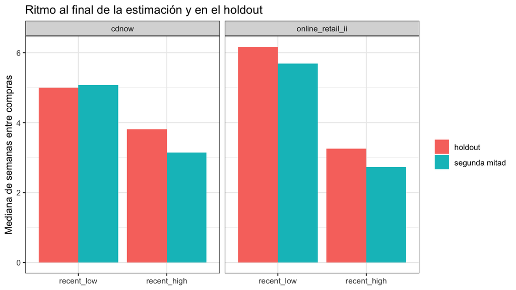

Ritmo al final de la estimación y en el holdout.

La hipótesis no se sostiene. En los 47 de CDNOW la mediana del cambio es 1.21 semanas y el 70% se vuelve más lento. Las medianas del grupo pasan de 3.14 a 3.81. La media del holdout sube a 5.33. Siguen siendo los de la tasa 11.11 y las 8.15 compras observadas.

En la mitad lenta la mediana del cambio es 1.45 semanas, con el 62% más lento. Las medianas del grupo quedan en 5.07 y 5.00.

En el minorista la mitad rápida también se alarga: mediana del cambio 0.54 semanas, del 2.73 al 3.26, y el 66% se vuelve más lento.

## 24 Limitaciones

- El contexto es sin contrato. Este marco no vale para suscripciones ni para préstamos, donde el abandono sí se observa.
- El holdout largo sigue siendo uno y no trae intervalo. En cuatro cortes con horizonte de 13 semanas el signo se repite (Pareto/NBD por debajo de BG/NBD, ambos por debajo del baseline), pero la ventaja sobre BG/NBD es menor que la dispersión entre cortes.
- El AIC en muestra y el MAE en holdout no eligen el mismo modelo. Se reportan los dos.
- El seguimiento acumulado ajusta bien y la calibración individual no. La subestimación en deciles bajos es una hipótesis.
- GGom/NBD colapsa al Pareto/NBD en CDNOW. Presentarlo como un modelo distinto inflaría la comparación.
- El Gamma/Gamma pide independencia entre gasto y frecuencia. El Spearman de 0.165 no la rompe y tampoco la confirma.
- El CLV publicado es de vida infinita. El horizonte del pronóstico no lo cambia.
- El benchmark normaliza ventanas de distinto largo (19 semanas de etiqueta en entrenamiento, unas 39 en test) y no afina hiperparámetros.
- En apparel el modelo dinámico mejora AIC y MAE de holdout (AIC 11525.9, MAE 1.858 frente a 11704.2 y 2.040 del modelo base). Los covariables son simulados. El contraste de verosimilitud solo muestra que el mecanismo responde. Solo el Pareto/NBD admite covariables dinámicas.
- La corrida usa R 4.6.0. La especificación se probó en R 4.3.3. Las tablas de BTYD, gasto, covariables y simulación coinciden con esa referencia en la precisión que publica. El MAE de XGBoost no, y el orden sí.

## 25 Reproducibilidad

Desde la raíz del repositorio, con R ≥ 4.3:

```bash
Rscript -e 'renv::restore()'
Rscript R/run_all.R
Rscript R/08_rolling_origin.R
Rscript R/09_uncertainty.R
Rscript R/10_online_retail.R
Rscript R/11_bnpl_merchants.R
Rscript R/12_recovery_by_n.R
Rscript R/13_identification.R
Rscript R/14_seasonality.R
Rscript R/15_ranking.R
Rscript R/16_holdout_rank.R
Rscript R/17_frequency_strata.R
Rscript R/18_short_age.R
Rscript R/19_recency_gap.R
Rscript R/20_rate_shrinkage.R
Rscript R/21_active_holdout.R
Rscript R/22_purchase_pace.R
Rscript R/23_within_pace.R
Rscript R/24_pace_continuation.R
Rscript -e 'targets::tar_make()'
Rscript -e 'shiny::runApp("shiny", launch.browser = TRUE)'
Rscript -e 'testthat::test_dir("tests/testthat", stop_on_failure = TRUE)'
quarto render reports/p7_clv.qmd
```

`targets::tar_make()` envuelve los scripts de CDNOW y las extensiones de ventanas móviles e incertidumbre, sin reescribir los modelos. La caché queda en `_targets/` y no se versiona. La primera corrida de esta máquina tardó 5 min 57 s (21 pasos). La siguiente, sin cambios, se saltó los 21 en 44 ms. Online Retail II no entra en esa caché: el xlsx no está en el repositorio. `run_all.R` sigue disponible sin esa capa.

Esta corrida: R version 4.6.0 (2026-04-24).

Versiones fijadas en renv.lock y usadas al renderizar.

| package | version |
| --- | --- |
| CLVTools | 0.12.1 |
| data.table | 1.18.6.1 |
| ggplot2 | 4.0.4 |
| xgboost | 3.2.1.1 |
| testthat | 3.3.2 |
| knitr | 1.52 |
| rmarkdown | 2.32 |
| renv | 1.3.1 |
| targets | 1.12.0 |
| shiny | 1.14.0 |
| DT | 0.34.0 |

CLVTools 0.12.1 es GPL-3 y entra como dependencia. El código de este repositorio está en MIT. Si el paquete se compila desde fuente hace falta GNU GSL; en esta máquina se usó el binario de CRAN. Los parámetros de `R/00_utils.R` (semilla 42, semana, descuento anual 0.10, corte de 39 semanas) no se cambiaron. Cada desvío de entorno está en `docs/decisiones.md`.